# Lab 3: Machine Learning III

## 1. Regression and Decision Trees for Continuous Outcomes

Before we begin, make sure that all of the following packages are installed on your computer:

- `caret`
- `dslabs`
- `GGally`
- `MASS`
- `pROC`
- `randomForest`
- `tidyverse`
- `tree`

In this part of the lab, we will predict infant birth weight using the `birthwt` dataset, available in the `MASS` package. This dataset of 189 observations was collected at the Baystate Medical Center in Springfield, MA during 1986. It includes the following variables:

- `low`: indicator of birth weight less than 2.5 kg (0 = more than 2.5 kg, 1 = less than 2.5 kg).
- `age`: mother’s age in years.
- `lwt`: mother’s weight in pounds at last menstrual period.
- `race`: mother’s race (1 = white, 2 = black, 3 = other).
- `smoke`: smoking status during pregnancy (0 = nonsmoker, 1 = smoker).
- `ptl`: number of previous premature labors.
- `ht`: history of hypertension (0 = no history, 1 = history of hypertension).
- `ui`: presence of uterine irritability (0 = no presence, 1 = presence of uterine irritability).
- `ftv`: number of physician visits during the first trimester.
- `bwt`: birth weight in grams.

```r
library(tidyverse)
library(caret)
library(tree)
library(MASS)

data(birthwt)
```

Since we are interested in predicting birth weight, we drop the `low` indicator from the dataset. We also convert `race`, `smoke`, `ht`, and `ui` to factors, because these variables are categorical and not numeric/continuous.

Comment: Both the `dplyr` and `MASS` packages export a function called `select`, which is why the `dplyr::` is necessary in `dplyr::select`. This makes it clear to R that we want to use the `select` function from `dplyr`.

```r
birthwt = birthwt %>% dplyr::select(-low) %>%
  mutate(race = factor(race),
         smoke = factor(smoke),
         ht = factor(ht),
         ui = factor(ui))
```

We use `createDataPartition` to split the birth weight data into equally-sized training and test sets.

```r
set.seed(9)
birthwt_index_train = createDataPartition(y = birthwt$bwt,
                                  times = 1, p = 0.5, list = FALSE)
birthwt_train_set = slice(birthwt, birthwt_index_train)
birthwt_test_set = slice(birthwt, -birthwt_index_train)
```

### Question 1.1

Based on the training set, make some plots to help you assess the relationship between our outcome of interest, `bwt`, and each of the other eight variables in the dataset. Which variables seem like good predictors of birth weight?

**Solution:**

For the continuous predictors (`age`, `lwt`, `ptl`, and `ftv`), we can make scatterplots to assess their relationships with infant birth weight.

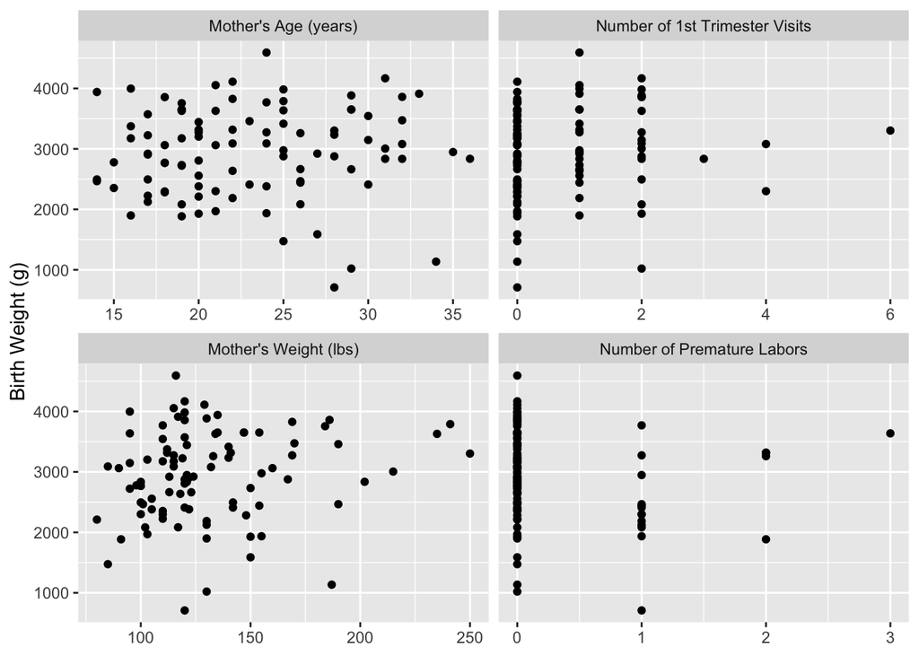

```r
birthwt_train_set %>%
  gather(predictor, value, c(age, lwt, ptl, ftv)) %>%
  ggplot(aes(x = value, y = bwt)) +
  geom_point() +
  facet_wrap(~ predictor, scales = 'free_x',
             labeller =
               as_labeller(c("age"="Mother's Age (years)",
                             "lwt" = "Mother's Weight (lbs)",
                             "ptl" = "Number of Premature Labors",
                             "ftv" = "Number of 1st Trimester Visits"))) +
  xlab(NULL) + ylab("Birth Weight (g)")
```

For the categorical predictors (`race`, `smoke`, `ht`, and `ui`), we can make boxplots. `ptl` (number of premature labors) and `ftv` (number of first trimester visits) are ordinal but not continuous, so they can also be visualized here as categorical predictors. You could potentially convert them to factors and have the models in Q1.2-1.4 treat them as categorical predictors, but we won’t overcomplicate things by doing that.

Comment: The warning message “attributes are not identical across measure variables; they will be dropped” comes from gathering the predictor variables, which are factors that have different levels. It can be safely ignored in this case.

```
## Warning: attributes are not identical across measure variables;
## they will be dropped
```

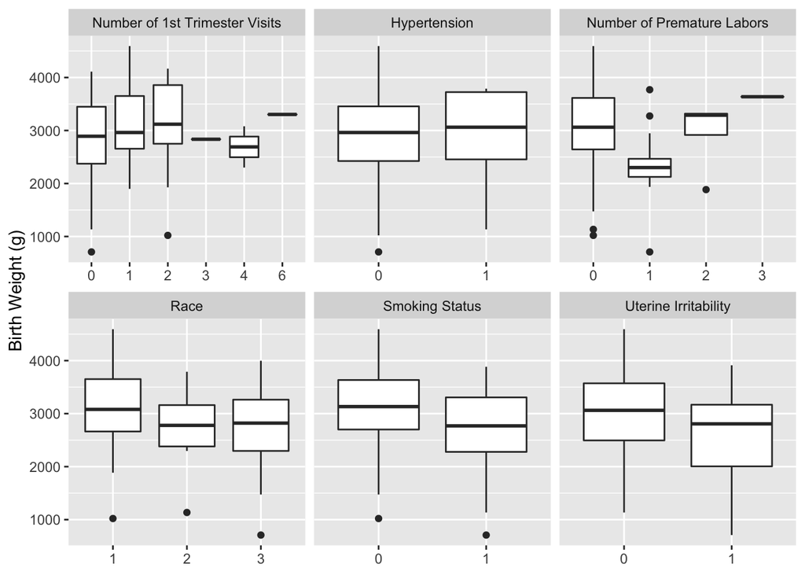

```r
birthwt_train_set %>%
  gather(predictor, value, c(race, smoke, ht, ui, ptl, ftv))  %>%
  ggplot(aes(x = value, y = bwt)) +
  geom_boxplot() +
  facet_wrap(~ predictor, scales = 'free_x',
             labeller =
               as_labeller(c("race"="Race",
                             "smoke" = "Smoking Status",
                             "ht" = "Hypertension",
                             "ui" = "Uterine Irritability",
                             "ptl" = "Number of Premature Labors",
                             "ftv" = "Number of 1st Trimester Visits"))) +
  xlab(NULL) + ylab("Birth Weight (g)")
```

It appears mothers who smoked during pregancy or experienced uterine irritability may be more likely have babies with low birth weights. A few of the other predictors look like the may be associated with birth weight too, like mother’s weight and race, but it’s hard to really say.

### Question 1.2

Fit a linear regression model with `lm` that predicts `bwt` using all of the other variables in the training data. Print out the summary information and identify variables with significant coefficients.

**Solution:**

The coefficients for `race3` (Other vs. White), `smoke1` (smoking vs. nonsmoking), and `ui1` (uterine irritability vs. not) are significant at a 0.05 threshold. This is consistent with what we observed in the EDA from Q1.1. However, the linear model may not be doing a good job of capturing more complex, non-linear associations.

```r
fit_lm = lm(bwt ~ . , data = birthwt_train_set)
summary(fit_lm)
```

```
##
## Call:
## lm(formula = bwt ~ ., data = birthwt_train_set)
##
## Residuals:
##      Min       1Q   Median       3Q      Max
## -1799.90  -424.58    -2.97   503.88  1275.02
##
## Coefficients:
##             Estimate Std. Error t value Pr(>|t|)
## (Intercept) 3327.773    440.834   7.549 4.29e-11 ***
## age          -12.860     15.012  -0.857   0.3940
## lwt            2.233      2.656   0.841   0.4028
## race2       -398.504    250.627  -1.590   0.1155
## race3       -422.426    168.661  -2.505   0.0141 *
## smoke1      -381.607    158.504  -2.408   0.0182 *
## ptl           77.718    139.953   0.555   0.5801
## ht1         -137.738    359.455  -0.383   0.7025
## ui1         -503.860    217.824  -2.313   0.0231 *
## ftv           39.813     73.121   0.544   0.5875
## ---
## Signif. codes:  0 '***' 0.001 '**' 0.01 '*' 0.05 '.' 0.1 ' ' 1
##
## Residual standard error: 698.5 on 86 degrees of freedom
## Multiple R-squared:  0.1998, Adjusted R-squared:  0.116
## F-statistic: 2.386 on 9 and 86 DF,  p-value: 0.01839
```

### Question 1.3

Fit a regression tree that predicts `bwt` using all of the other variables in the training data. You can use the `tree` function from the `tree` package. Make a plot that visualizes the tree, and compare the variables used to construct the tree with the variables that were significant in the linear model from Q1.2.

**Solution:**

The code for fitting a decision tree with `tree` follows a very similar syntax as the code for fitting a linear model with `lm`. When visualizing the tree, `pretty = 0` forces the text labels to use the factor level names stored in the categorical variables, instead of `a, b, ..., z`.

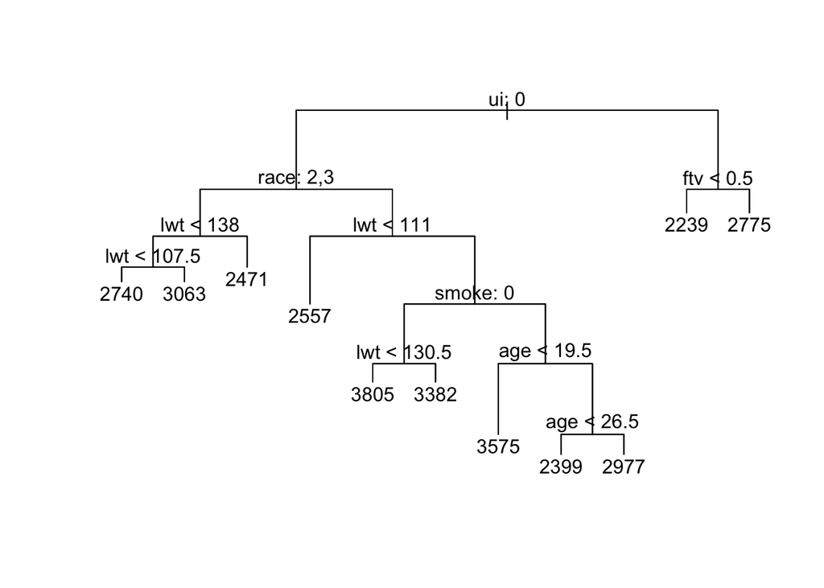

```r
fit_regtree = tree(bwt ~ ., data = birthwt_train_set)

plot(fit_regtree)
text(fit_regtree, pretty = 0)
```

The regression tree was constructed using `ui`, `race`, `lwt`, `smoke`, `age`, and `ftv`. This includes all three of the variables that we identified as being significant in the linear model, plus a few others.

```r
summary(fit_regtree)
```

```
##
## Regression tree:
## tree(formula = bwt ~ ., data = birthwt_train_set)
## Variables actually used in tree construction:
## [1] "ui"    "race"  "lwt"   "smoke" "age"   "ftv"
## Number of terminal nodes:  11
## Residual mean deviance:  384800 = 32710000 / 85
## Distribution of residuals:
##     Min.  1st Qu.   Median     Mean  3rd Qu.     Max.
## -1754.00  -337.80    57.23     0.00   320.80  1398.00
```

### Question 1.4

Use the `cv.tree` function to determine a reasonable tree size. Be sure to set a random seed so that your code is reproducible (the solutions use `set.seed(16)`). Prune your tree from Q1.3 to have this “best” size, using the `best` argument in the `prune.tree` function. Visualize the pruned tree and compare the variables used to construct it with the variables used to construct the tree from Q1.3.

**Solution:**

The cross-validation deviance appears to be minimized when the tree has 6 terminal nodes. This is about half as many terminal nodes as there were in the original tree. Different random seeds can lead to different plots and conclusions.

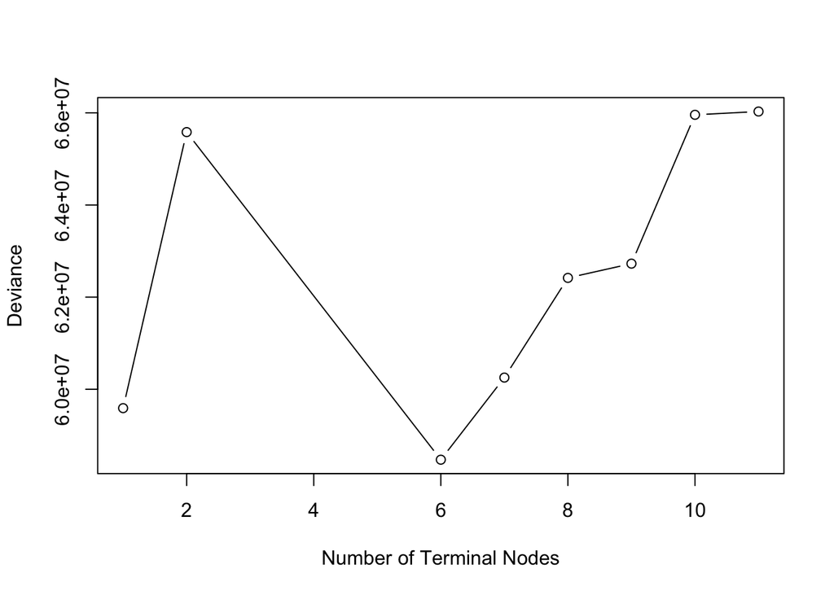

```r
set.seed(16)
cv_regtree = cv.tree(fit_regtree)
plot(cv_regtree$size, cv_regtree$dev, type = 'b',
     xlab="Number of Terminal Nodes", ylab="Deviance")
```

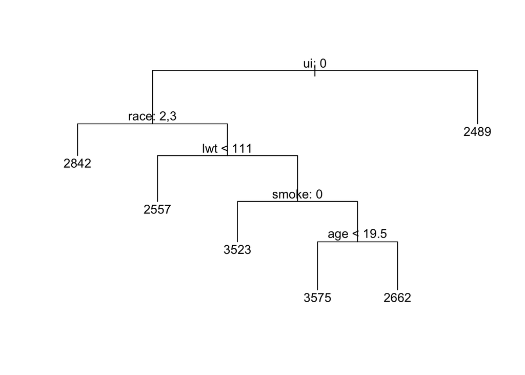

```r
fit_regtree_prune = prune.tree(fit_regtree, best = 6)

plot(fit_regtree_prune)
text(fit_regtree_prune, pretty = 0)
```

```r
summary(fit_regtree_prune)
```

```
##
## Regression tree:
## snip.tree(tree = fit_regtree, nodes = c(22L, 47L, 3L, 4L))
## Variables actually used in tree construction:
## [1] "ui"    "race"  "lwt"   "smoke" "age"
## Number of terminal nodes:  6
## Residual mean deviance:  417800 = 37610000 / 90
## Distribution of residuals:
##     Min.  1st Qu.   Median     Mean  3rd Qu.     Max.
## -1780.00  -435.30    28.67     0.00   418.20  1423.00
```

### Question 1.5

For each of the three models from Q1.2-4, calculate birth weight predictions for the observations in the test set. Compare model performance in terms of the test mean-squared error (MSE).

**Solution:**

You can get predictions for each these three models with a straightforward application of the `predict` function. The linear regression model has a test MSE of 408096.8.

```r
preds_lm = predict(fit_lm, newdata = birthwt_test_set)
mean((preds_lm - birthwt_test_set$bwt)^2)
```

```
## [1] 408096.8
```

The unpruned regression tree has a test MSE of 446478.5, which is higher than that of linear regression.

```r
preds_regtree = predict(fit_regtree, newdata = birthwt_test_set)
mean((preds_regtree - birthwt_test_set$bwt)^2)
```

```
## [1] 446478.5
```

Pruning the regression tree to have 6 terminal nodes results in a test MSE of 402471.2, which is an improvement over the unpruned tree’s test MSE and slightly better than the linear regression test MSE.

```r
preds_regtree_prune = predict(fit_regtree_prune, newdata = birthwt_test_set)
mean((preds_regtree_prune - birthwt_test_set$bwt)^2)
```

```
## [1] 402471.2
```

Advanced: you can use apply functions to cut down on the redundant code.

```r
sapply(list("Linear regression" = fit_lm,
            "Regression tree" = fit_regtree,
            "Pruned regression tree" = fit_regtree_prune),
       function(mod) {
         pred = predict(mod, newdata = birthwt_test_set)
         mean((pred - birthwt_test_set$bwt)^2)
})
```

```
##      Linear regression        Regression tree Pruned regression tree
##               408096.8               446478.5               402471.2
```

## 2. Decision Trees, Bagging, and Random Forests for Multi-Class Outcomes

In the final section of this lab, we will use gene expression data to classify tissue samples. The data can be loaded from the `dslabs` package by calling `data(tissue_gene_expression)`. `tissuesGeneExpression` is a list with two elements:

- `x`: Numeric matrix with 189 rows and 500 columns. Each column contains gene expression measurements for a different gene.
- `y`: Factor vector of length 189 that records tissue type labels (cerebellum, colon, endometrium, hippocampus, kidney, liver, or placenta) .

The original data (accessible in the `tissuesGeneExpression` package) records gene expression for 22,215 genes.

```r
library(tidyverse)
library(caret)
library(GGally)
library(tree)
library(randomForest)
library(dslabs)

data(tissue_gene_expression)
```

We will only use a random sample of 100 genes to predict tissue type.

```r
set.seed(25)
tiss_ge = data.frame(y = tissue_gene_expression$y,
                     tissue_gene_expression$x[,sample(500, 100)])
```

As usual, we split the data into training and test sets, each with about 50% of the data.

```r
set.seed(36)
tiss_ge_index_train = createDataPartition(y = tiss_ge$y,
                                  times = 1, p = 0.5, list = FALSE)
tiss_ge_train_set = slice(tiss_ge, tiss_ge_index_train)
tiss_ge_test_set = slice(tiss_ge, -tiss_ge_index_train)
```

### Question 2.1

Below, you will find some plots and tables of the training set designed to help you develop some intuition for the data. Describe what you see.

This is a frequency table for the tissue types in the training data.

```r
table(tiss_ge_train_set$y)
```

```
##
##  cerebellum       colon endometrium hippocampus      kidney       liver
##          19          17           8          16          20          13
##    placenta
##           3
```

It is difficult to make visualizations for all 100 genes in the dataset, so let’s randomly sample six to focus on.

```r
set.seed(49)
genes6 = sample(names(tiss_ge)[-1], 6)
genes6
```

```
## [1] "CAMK1G" "COPB1"  "LGALSL" "RPE65"  "GNA11"  "MYL7"
```

Here are histograms of the gene expression distributions of the six genes.

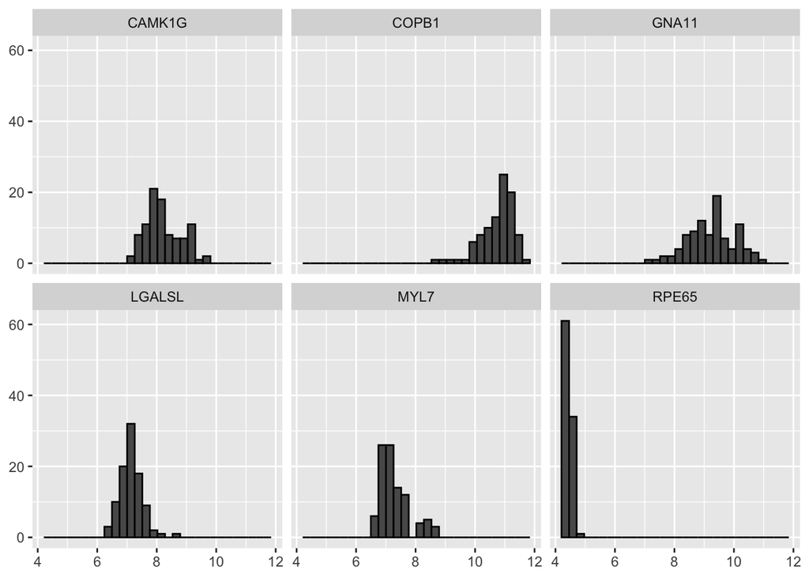

```r
tiss_ge_train_set %>%
  gather(gene, expression, all_of(genes6))  %>%
  ggplot(aes(x = expression)) +
  geom_histogram(color = "black") +
  facet_wrap(~ gene) +
  xlab(NULL) + ylab(NULL)
```

The boxplots below plot gene expression against tissue type for the six genes. Note that setting `scales = 'free_y'` allows the y-axis to vary from plot to plot, so they are not on the same scale.

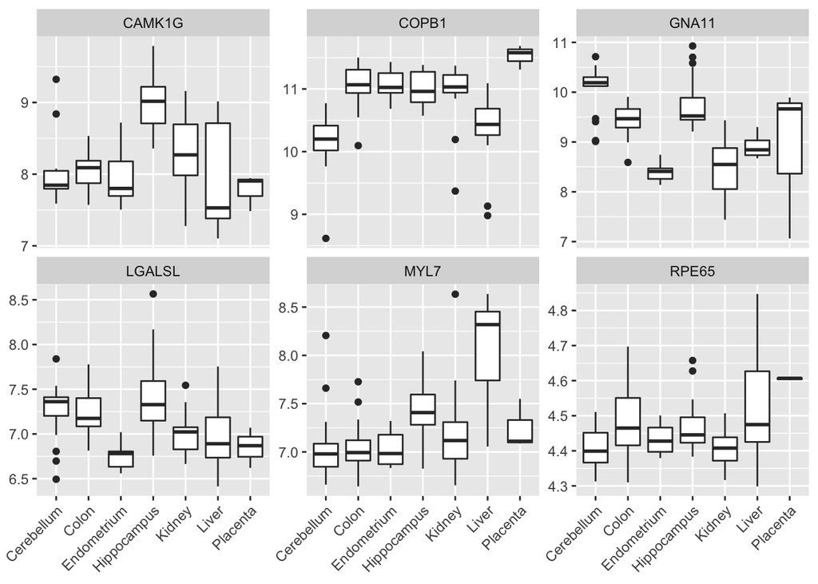

```r
tiss_ge_train_set %>%
  gather(gene, expression, all_of(genes6))  %>%
  ggplot(aes(x = y, y = expression)) +
  geom_boxplot() +
  facet_wrap(~ gene, scales = 'free_y') +
  xlab(NULL) + ylab(NULL) +
  scale_x_discrete(labels = str_to_title(unique(tiss_ge_train_set$y))) +
  theme(axis.text.x = element_text(angle = 45, hjust=1))
```

The `ggcorr` function from the `GGally` package makes pretty correlation matrix plots. Each tiny square in this plot represents the correlation between a pair of genes (out of the entire set of 100 genes). Red indicates positive correlation (close to 1), blue indicates negative correlation (close to -1), and white indicates no correlation (close to 0).

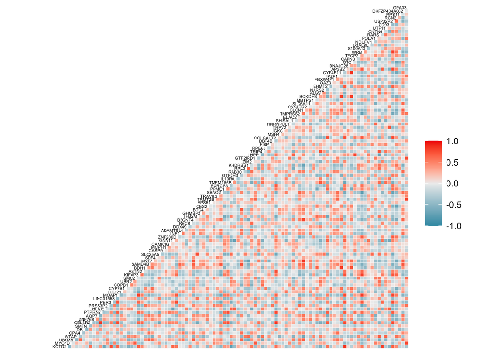

```r
ggcorr(tiss_ge_train_set[,-1], hjust = 1, size = 1.5, layout.exp = 10)
```

**Solution:**

- From the frequency table, we can see that there is a non-uniform distribution of tissue types. Some tissues, like cerebellum and kidney, are much better represented in the data than others, like endometrium and placenta.
- The histograms show that the gene expression measurements of the six randomly sampled genes have different distributions. Some are roughly symmetric, while others are skewed. COPB1 is highly expressed in most of the tissues, while RPE65 tends to be lowly expressed.
- The boxplots suggest that individual genes are often expressed at different levels for different tissues. However, it doesn’t really seem like any one of these six genes does a great job of distinguishing between all seven of the tissue types.
- The correlation matrix plot (lots of red and blue squares) illustrates that many of the genes in this dataset are highly correlated with each other. So, we might not need all of the predictors to do a good job of classifying the tissues.

### Question 2.2

Using the `tree` function from the `tree` package and all of the training set gene expression data, build a decision tree to classify the tissue types. Get the predicted class labels for the test set data, report the test accuracy, and comment on the test confusion matrix.

**Solution:**

```r
fit_classtree = tree(y ~ . , data = tiss_ge_train_set)
```

To get predicted class labels and not the predicted probabilities, be sure to specify `type = "class"` in the `predict` function.

```r
preds_fit_classtree = predict(fit_classtree, newdata = tiss_ge_test_set,
                              type = "class")
```

The decision tree’s test set accuracy as reported by `confusionMatrix` is 0.914, which is quite good. From the confusion matrix, we can see that our model classifies the cerebellum, colon, and hippocampus tissues in the test set perfectly, but makes a some mistakes when it comes to endometrium, kidney, liver, and placenta.

```r
confusionMatrix(preds_fit_classtree, tiss_ge_test_set$y)
```

```
## Confusion Matrix and Statistics
##
##              Reference
## Prediction    cerebellum colon endometrium hippocampus kidney liver placenta
##   cerebellum          19     0           0           0      0     0        0
##   colon                0    17           0           0      0     0        0
##   endometrium          0     0           5           0      0     0        2
##   hippocampus          0     0           0          15      0     0        0
##   kidney               0     0           1           0     19     1        0
##   liver                0     0           1           0      0     9        0
##   placenta             0     0           0           0      0     3        1
##
## Overall Statistics
##
##                Accuracy : 0.914
##                  95% CI : (0.8375, 0.9621)
##     No Information Rate : 0.2043
##     P-Value [Acc > NIR] : < 2.2e-16
##
##                   Kappa : 0.8964
##
##  Mcnemar's Test P-Value : NA
##
## Statistics by Class:
##
##                      Class: cerebellum Class: colon Class: endometrium
## Sensitivity                     1.0000       1.0000            0.71429
## Specificity                     1.0000       1.0000            0.97674
## Pos Pred Value                  1.0000       1.0000            0.71429
## Neg Pred Value                  1.0000       1.0000            0.97674
## Prevalence                      0.2043       0.1828            0.07527
## Detection Rate                  0.2043       0.1828            0.05376
## Detection Prevalence            0.2043       0.1828            0.07527
## Balanced Accuracy               1.0000       1.0000            0.84551
##                      Class: hippocampus Class: kidney Class: liver
## Sensitivity                      1.0000        1.0000      0.69231
## Specificity                      1.0000        0.9730      0.98750
## Pos Pred Value                   1.0000        0.9048      0.90000
## Neg Pred Value                   1.0000        1.0000      0.95181
## Prevalence                       0.1613        0.2043      0.13978
## Detection Rate                   0.1613        0.2043      0.09677
## Detection Prevalence             0.1613        0.2258      0.10753
## Balanced Accuracy                1.0000        0.9865      0.83990
##                      Class: placenta
## Sensitivity                  0.33333
## Specificity                  0.96667
## Pos Pred Value               0.25000
## Neg Pred Value               0.97753
## Prevalence                   0.03226
## Detection Rate               0.01075
## Detection Prevalence         0.04301
## Balanced Accuracy            0.65000
```

### Question 2.3

Fit a bagging (bootstrap aggregation) model to the training data by running `randomForest` from the `randomForest` package with the `mtry` parameter set to the number of predictors (`mtry = 100`). Be sure to set a random seed so that your code is reproducible (the solutions use `set.seed(64)`). Get the predicted class labels for the test set data and report the test accuracy.

**Solution:**

Setting `mtry = 100` when we have 100 predictors is what makes this model a bagging model.

```r
set.seed(64)
fit_bag = randomForest(y ~ ., data = tiss_ge_train_set, mtry = 100)
```

By default, the `predict` function for `randomForest` models returns predicted class labels, but you can also explicitly specify `type = "response"`.

```r
preds_fit_bag = predict(fit_bag, newdata = tiss_ge_test_set)
```

You can use the `confusionMatrix` function to calculate diagnostic metrics for the test set predictions and pull out the accuracy from the `overall` slot.

```r
confusionMatrix(preds_fit_bag, tiss_ge_test_set$y)$overall[1]
```

```
##  Accuracy
## 0.9892473
```

Alternatively, you can use the predicted and true test labels to calculate the accuracy by hand.

```r
mean(preds_fit_bag == tiss_ge_test_set$y)
```

```
## [1] 0.9892473
```

Either way, the test accuracy is 0.989, which is better than the test accuracy we got from the single classification tree.

### Question 2.4

Now, build a random forest model with the `mtry` parameter set to the square root of the number of predictors. Also, set `importance = TRUE` so that the importance of the predictors is assessed. You will need the variable importance information for Q2.5. Be sure to set a random seed so that your code is reproducible (the solutions use `set.seed(81)`). Get the predicted class labels for the test set data and report the test accuracy.

**Solution:**

For classification problems, the default value for `mtry` is the square root of the number of predictors, but we can explicitly specify `mtry = 10`.

```r
set.seed(81)
fit_rf = randomForest(y ~ ., data = tiss_ge_train_set,
                      mtry = 10, importance = TRUE)
```

As in Q2.3, you can calculate the accuracy directly or by using the `confusionMatrix` function. Here, the test accuracy is 1, meaning that all of the test set observations were classified perfectly by the model. We know from Q2.1 that the genes are highly correlated with each other. Random forests are known to decorrelate predictors, which explains the improvement over bagging.

```r
preds_fit_rf = predict(fit_rf, newdata = tiss_ge_test_set)

confusionMatrix(preds_fit_rf, tiss_ge_test_set$y)$overall[1]
```

```
## Accuracy
##        1
```

```r
mean(preds_fit_rf == tiss_ge_test_set$y)
```

```
## [1] 1
```

### Question 2.5

Run the `importance` function on your random forest model from Q2.4 to extract variable importance measures for each of the tissue types. Find the five most important genes for classifying kidney tissues by ordering the Gini index measures. Compare these five genes with the genes that were used to construct the classification tree in Q2.2.

Optional: Extract the five most important genes for each of the seven tissues, and compare these results with the genes that were used to construct the classification tree in Q2.2.

**Solution:**

The five most important genes for classifying kidney tissues are COLGALT2, GPA33, CES2, PRSS3P2, and CELSR2.

```r
variable_importance = importance(fit_rf)

variable_importance_kidney =
  data.frame(gene = rownames(variable_importance),
             Gini = variable_importance[,"kidney"])

variable_importance_kidney %>%
  arrange(desc(Gini)) %>% head(5)
```

```
##              gene     Gini
## COLGALT2 COLGALT2 8.806277
## GPA33       GPA33 7.517900
## CES2         CES2 6.929652
## PRSS3P2   PRSS3P2 6.896391
## CELSR2     CELSR2 6.279366
```

Six genes were used to construct the decision tree from Q2.2. Of these, COLGALT2, GPA33, and CES2 overlap with the five most important variables for classifying kidney tissues in the random forest model.

```r
summary(fit_classtree)
```

```
##
## Classification tree:
## tree(formula = y ~ ., data = tiss_ge_train_set)
## Variables actually used in tree construction:
## [1] "COLGALT2" "GPA33"    "HNRNPUL1" "UBOX5"    "CES2"     "CAPN3"
## Number of terminal nodes:  7
## Residual mean deviance:  0.07562 = 6.73 / 89
## Misclassification error rate: 0.02083 = 2 / 96
```

If we extract the top five genes for each of the seven tissues, we can see that all but one of the genes used to construct the classification tree are represented. The lone exception is UBOX5. There are some additional surprises; for example, CELSR2 is considered to be one of the most important genes for classifying five out of the seven tissues in random forest, but was not used by the decision tree.

```r
variable_importance_long =
  data.frame(gene = rownames(variable_importance),
             variable_importance) %>%
  gather(tissue, Gini, unique(tiss_ge_train_set$y))

variable_importance_long %>%
  group_by(tissue) %>%
  slice_max(order_by = Gini, n = 5) %>%
  ungroup() %>%
  dplyr::select(gene) %>%
  table()
```

```
## gene
##    AP3B2     BDH1    CAPN3   CELSR2     CES2 COLGALT2  CYP4F11    GPA33
##        3        1        1        5        3        6        1        2
## GTF2IRD1 HNRNPUL1    KCTD2    MYO1D      OTC  PRSS3P2   PTPRN2     RCN2
##        1        1        1        2        1        1        1        1
##    TRIP4   TRMT2B     WTAP
##        1        2        1
```